# Summary

# Introduction

The main purpose of this study is to set a groundwork for exploring effectiveness and feasibility of sampling methods in the educational field. Using real population data we compare simple random sampling (SRS), convenience sampling (CS), stratified balanced sampling (SBS), stratified simple random sampling (SSRS), and stratified convenience sampling (SCS). Our findings suggest that SBS and SSRS are extremely difficult to implement at low response rates, but result in highly generalizable samples. SRS and SCS are similar in both feasibility and effectiveness, however, stratification offers other advantages beyond generalizability (transparency).

We found several limitations in that we lack empricical precident for modeling both researcher behavior in recruiting sites, and site behavior in deciding to participate. This work underlines the importance of further research into answering (1) How do we model convenience smapling? and (2) How do schools and districts devide to participate in studies? We argue that reserachers should allocate more funding towards recruitment given the clear increaes in abilty to generalize a sample.

# Methods Summary

## Participation Generating Model

Distribution of propensity scores by response rates

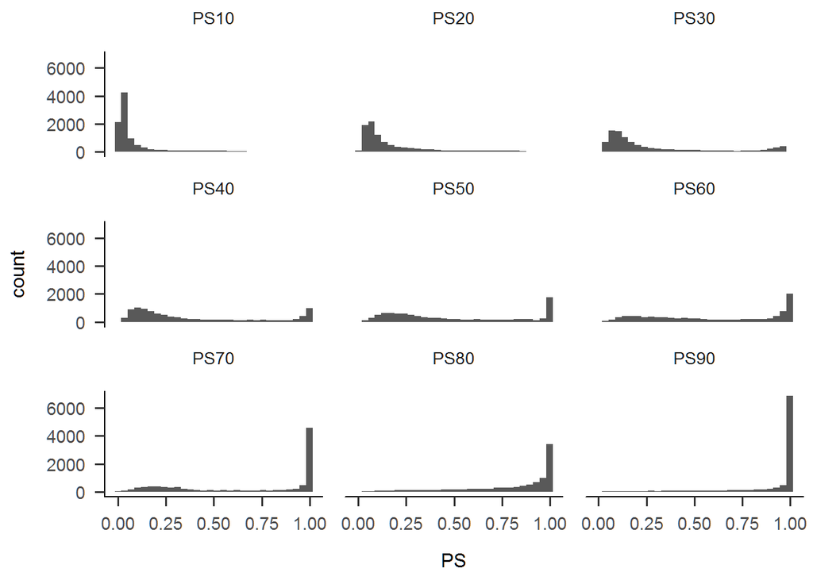

## Sampling Method

Recruitment is performed by rearanging the full list of schools and sampling from the list in order until 60 schools agree to participate. This enables the calculation of the total number of schools contacted for recruitment. Schools are arranged in order of Sampling, which is regenerated in each iteration. Sampling generation depends on the sampling method being simulated. In SRS school Samplings are randomly assigned. In CS, schools are sampled without replacement one at a time and assigned consecutive Samplings. Sampling is weighed by the propensity to participate so that schools that are more likely to participate are also more likely to be sampled earlier. Stratified versions of these methods first group schools into clusters, then generate Samplings within each cluster independantly. Schools are sampled until proportional sampling allocation is satisfied. Finally, in SBS schools are grouped into clusters and then Samplinged in order using a distance metric. These Samplings do not vary across iterations in the same conditions.

### Simple Random Sampling

1. Schools are randomly Samplinged.
2. Schools are approached in order of Sampling until 60 schools agree to participate.

### Convenience Sampling

1. Schools are Samplinged by sampling without replacement one school at a time.
2. Schools with higher propensity to participate are more likely to be Samplinged higher.
3. Schools are approached in order of Sampling until 60 schools agree to participate.

### Stratified Balanced Sampling

1. Schools are grouped by cluster.
2. Within each cluster, schools are Samplinged using distance metric.
3. Schools are approached in order of Sampling until number of schools as defined by proportional sampling allocation agree to participate.

### Stratified Simple Random Sampling

1. Schools are grouped by cluster.
2. Within each cluster, schools are randomly Samplinged.
3. Schools are approached in order of Sampling until number of schools as defined by proportional sampling allocation agree to participate.

1. Schools are grouped by cluster.
2. Schools are Samplinged by sampling without replacement one school at a time.
3. Schools with higher propensity to participate are more likely to be Samplinged higher.
4. Schools are approached in order of Sampling until number of schools as defined by proportional sampling allocation agree to participate.

## B Index

```
## # A tibble: 5 x 10
## # Groups:   sample [5]
##   sample               `10`  `20`  `30`  `40`  `50`  `60`  `70`  `80`  `90`
##   <chr>               <int> <int> <int> <int> <int> <int> <int> <int> <int>
## 1 Convenience Sampli~    NA    NA    NA    NA    NA    NA    NA    NA     2
## 2 S_Balanced Sampling    19     6     2    41     1    55     1    NA    NA
## 3 S_Convenience Samp~    NA    NA    NA    NA    NA    NA    NA     4    27
## 4 S_Simple Random Sa~    NA    NA    NA    NA     1     3    14    17    39
## 5 Simple Random Samp~    NA    NA    NA    NA    NA    NA     1     4     4
```

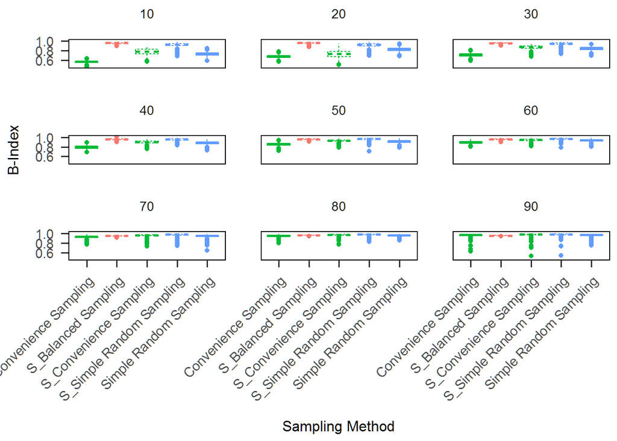

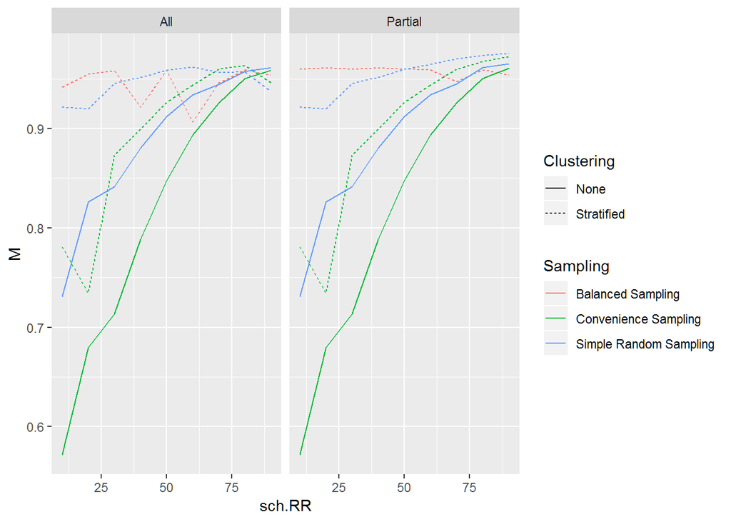

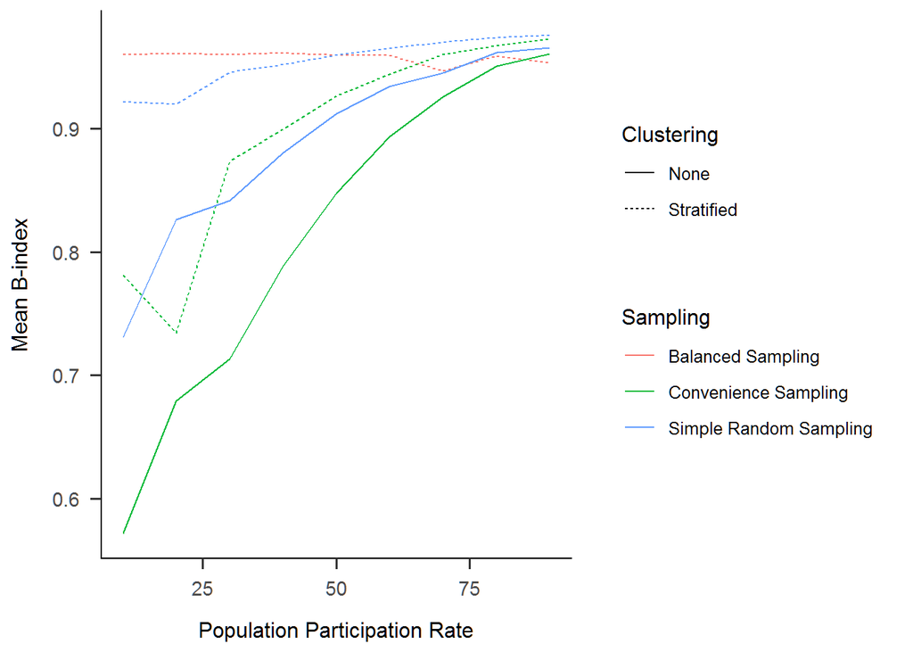

## Standardized mean differences

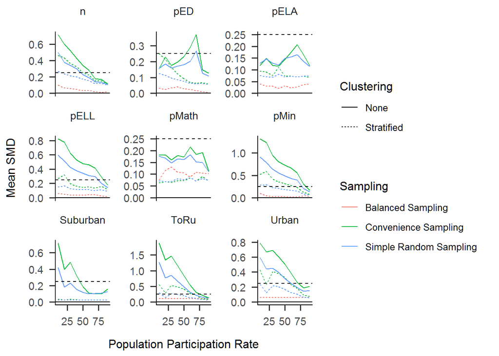

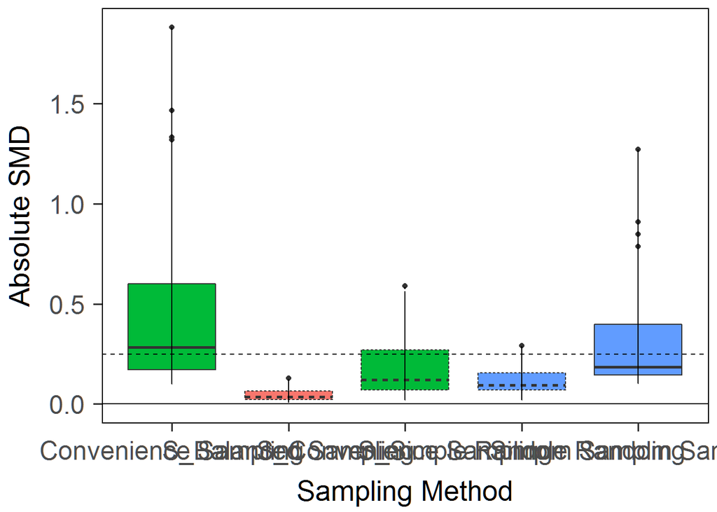

## Sampling Difficulty

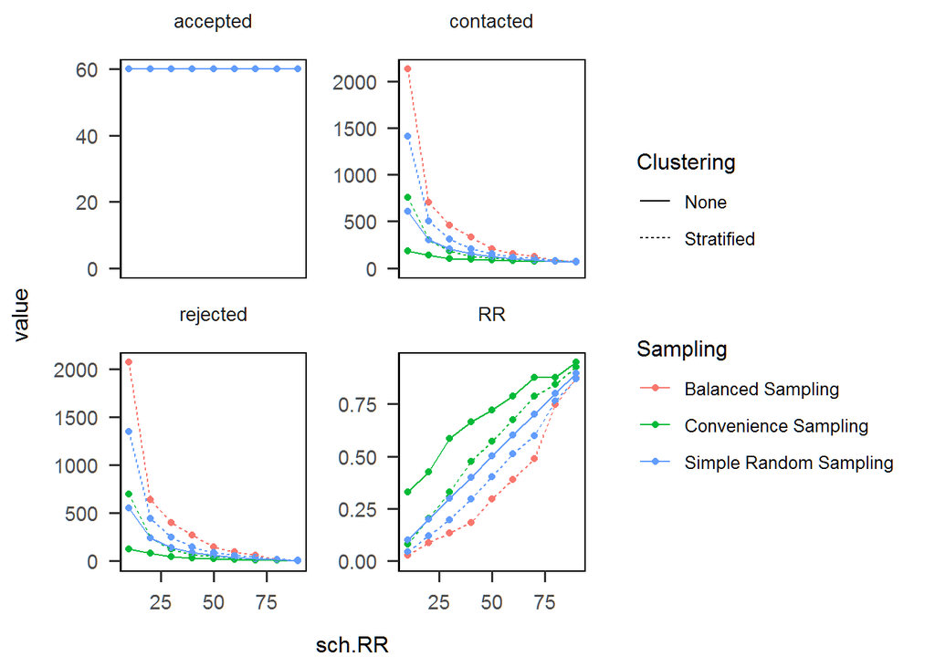

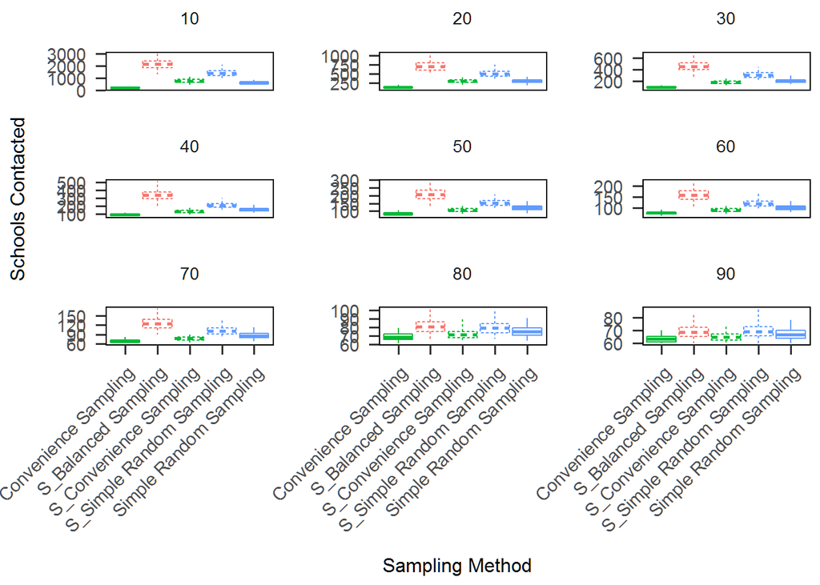

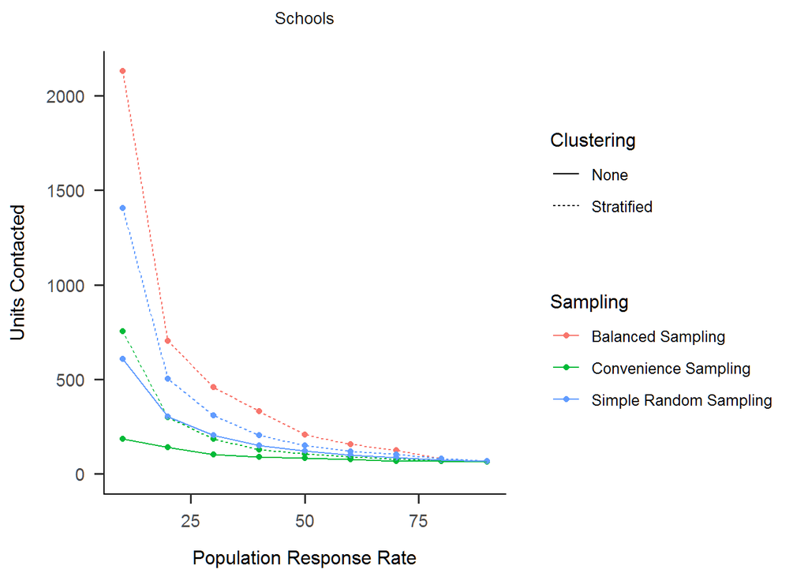

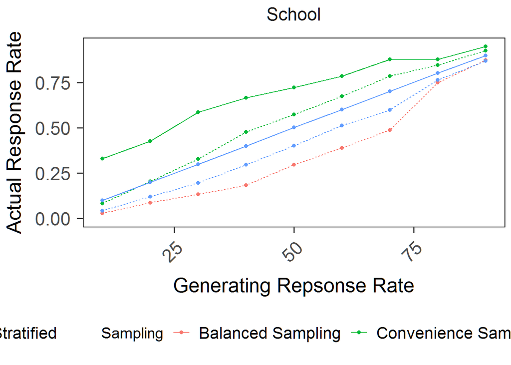